# STAT340 Discussion 13: the Bootstrap

Keith Levin

Fall 2023

In lecture, we saw the (possibly magical?) bootstrap, which, under certain circumstances, allows us to make inferences about a population-level quantity of interest (e.g., the Poisson parameter $\lambda$) by resampling from our data *as though it were the population itself*.

This is indeed a really paradoxical thing! How on earth can it be that we learn more about a quantity of interest by reusing the same data over and over?

As we said in lecture, the mathematical details explaining why the bootstrap works and under what circumstances will have to wait until later in your statistical career.

In this discussion section, though, you’ll get some practice implementing the bootstrap yourself, using it to construct a confidence interval, and develop an intuition for how to choose the number of bootstrap replicates $B$.

## Bootstrapping the correlation coefficient.

Suppose that we have random pairs $(X_i,Y_i)$, $i=1,2,\dots,n$ drawn iid from some distribution, and we are interested in estimating the correlation coefficient of the pairs,
$$\rho = \frac{ \operatorname{Cov}(X,Y) }{ \sqrt{ \sigma^2_X * \sigma^2_Y}
}
= \frac{ \mathbb{E} X_1 Y_1 - \mathbb{E} X_1 \mathbb{E} Y_1 }
{ \sqrt{ \sigma^2_X * \sigma^2_Y} },$$
where
$$\sigma^2_X = \operatorname{Var} X_1
~~~\text{ and }~~~
\sigma^2_Y = \operatorname{Var} Y_1$$

Here’s some code that generates $(X,Y)$ pairs from a two-dimensional normal distribution.

```r
generate_normal_pairs <- function( n, muX, muY, CovMx ) {
  data <- mvrnorm( n=n, mu=c(muX, muY), Sigma=CovMx );
  # Put the X and Y data into their own columns in a data frame, just to be fancy
  df <- data.frame( 'X' = data[,1], 'Y'=data[,2] );
  return(df);
}

muX <- 1;
muY <- -1;
sigma2XX <- 2;
sigma2YY <- 1;
sigmaXY <- -0.75

Sigma <- matrix( c(sigma2XX, sigmaXY, sigmaXY, sigma2YY), nrow = 2);
generate_normal_pairs( 5, muX, muY, Sigma );
```

```
##            X           Y
## 1  0.9099229 -1.31797884
## 2  2.5937270 -1.59548590
## 3  1.8913540  0.72816901
## 4  2.0503781 -1.34664523
## 5 -0.5358330  0.07811545
```

Note that we can read the variances and covariance off of the covariance matrix $\Sigma$ as
$$\Sigma = \begin{bmatrix} \sigma^2_X & \sigma_{XY} \\
\sigma_{XY} & \sigma^2_Y \end{bmatrix},$$
So plugging in our choices of variances and covariances in the code above, we have
$$\Sigma = \begin{bmatrix} 2 & -0.75 \\
-0.75 & 1 \end{bmatrix},$$
and, similarly plugging into the definition of $\rho$,
$$\rho = \frac{ -0.75 }{ \sqrt{2} } \approx -0.53.$$
Specifically,

```r
rhotrue <- sigmaXY/sqrt( sigma2XX * sigma2YY );
rhotrue
```

```
## [1] -0.5303301
```

So, here’s some data for us to work with from this model.

```r
original_data <- generate_normal_pairs( 100, muX, muY, Sigma );
head(original_data)
```

```
##            X           Y
## 1 -0.3915321  0.39922607
## 2  2.0374427 -0.44560732
## 3 -0.7566489 -0.07019286
## 4  0.4964880  0.18508792
## 5  2.6216975 -2.21476815
## 6 -3.5545522  0.41467705
```

Let’s use this data to estimate $\rho$.

Just like in our estimation of $\alpha$ in lecture, we can use the plug-in principle to estimate $\rho$ as
$$\hat{\rho}
= \frac{ \hat{\sigma}_{XY} }{ \sqrt{ \hat{\sigma}^2_X \hat{\sigma}^2_Y}
},$$
where
$$\begin{aligned}
\hat{\sigma}^2_X &= \frac{1}{n-1} \sum_{i=1}^n (X_i - \bar{X})^2 \\
\hat{\sigma}^2_Y &= \frac{1}{n-1} \sum_{i=1}^n (Y_i - \bar{Y})^2 \\
\hat{\sigma}_{XY} &= \frac{1}{n-1} \sum_{i=1}^n (X_i - \bar{X} )(
Y_i - \bar{Y}).
\end{aligned}$$
Implementing that in code,

```r
compute_rhohat <- function( data ) {
  # Assume data is a data frame with columns X and Y.

  # Get the sample covariance matrix of the data.
  # This includes the variances AND the covariance term we want.
  Sigmahat <- cov(data);
  # Pull the variance and covariance estimates out of the covariance matrix.
  sigma2hatXX <- Sigmahat[1,1];
  sigma2hatYY <- Sigmahat[2,2];
  sigmahatXY <- Sigmahat[1,2];

  rhohat <- sigmahatXY/sqrt( sigma2hatXX * sigma2hatYY);
  return( rhohat );
}

rhohat_original <- compute_rhohat( original_data );
rhohat_original
```

```
## [1] -0.6391894
```

But of course, a point estimate isn’t enough. We want a confidence interval for $\rho$.

## Refresher: simulation-based inference

Well, we know the true distribution of this data– after all, we generated it ourselves! So as a warm-up, let’s construct a simulation-based confidence interval for $\rho$, first.

Remember, the recipe is:

1. Estimate the model parameters
2. Generate “fake” data under that model.
3. Evaluate our estimator on the fake data
4. Repeat steps 2 and 3 many times and use the resulting replicates to estimate the variance

Okay, so let’s do that. First, we need to estimate the normal parameters ($\mu_X, \mu_Y$ and $\Sigma$) from the data.

```r
# The means are easy.
muXhat <- mean(original_data$X)
muYhat <- mean(original_data$Y)
# The cov function gets the sample covariance matrix, which is the right choice
# of estimator for the true matrix Sigma.
# You'll see why in your theory courses. For now, take this on faith.
Sigmahat <- cov( original_data );
```

Okay, now it’s time to generate replicates. Complete the code below appropriately.

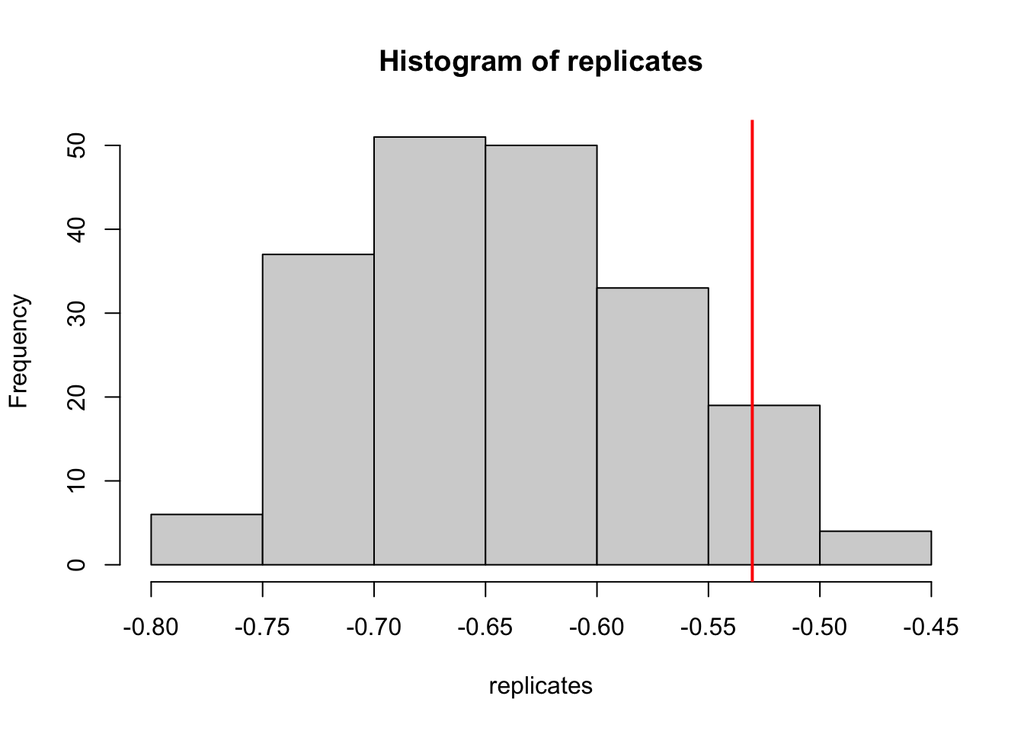

```r
N_MC <- 200;
nsamp <- nrow(original_data);
replicates <- rep( NA, N_MC );
for( i in 1:N_MC ) {
  #muhat <- c(0,0);
  # TODO: Comment or delete the line above. It's just there so the file knits.
  # Uncomment the next line and specify the vector muhat correctly.
  muhat <- c(muXhat, muYhat);

  #Sigmahat <- matrix(c(1,0,0,1),nrow=2);
  # TODO: Comment or delete the line above. It's just there so the file knits.
  # Uncomment the next line and specify Sigmahat correctly.
  Sigmahat <- Sigmahat
  fake_data <- mvrnorm(n=nsamp, mu=muhat, Sigma=Sigmahat);
  replicates[i] <- compute_rhohat(fake_data);
}

hist(replicates);
# TODO: Edit this next line to put a vertical line at our point estimate of rho
# computed on the original data.
abline( v=rhotrue, lwd=2, col='red')
```

Now, use the replicates to construct a 95% CI for $\rho$.

```r
simulation_CI = unname(quantile(replicates, c(.025, .975) ))
simulation_CI
```

```
## [1] -0.7518810 -0.5132757
```

Does your CI contain the true value of $\rho$?

Depends on the random seed

What is the width of your CI? We will need this information later on.

```r
simulation_CI[2] - simulation_CI[1]
```

```
## [1] 0.2386053
```

### Validation

Now, the natural next step would be to run the experiment we’ve seen so many times this semester– repeat the above procedure many times and measure how often we successfully catch the true value of $\rho$.

But you’ve seen the above example before, and it’s beside the point. Everything is nice in the example above, and we’re here to do the bootstrap!

**Optional exercise (at home):** write code to repeat the above experiment many times and record how often our simulation-based CI “catches” $\rho$ correctly. Don’t forget that you need to generate a new random copy of `original_data` for each experimental trial, otherwise you’re not estimating the right probability!

## Bootstrapping $\hat{\rho}$

Okay, now let’s get a CI using the bootstrap, and compare.

Remember, the bootstrap recipe is:

1. Obtain a bootstrap sample by sampling with replacement from the data
2. Compute our statistic on the bootstrap sample
3. Repeat steps 1 and 2 many times.
4. Use the resulting bootstrap replicates to estimate the variance.

The following code has a number of errors in it. Correct them so that we correctly compute 200 bootstrap replicates of $\hat{\rho}$.

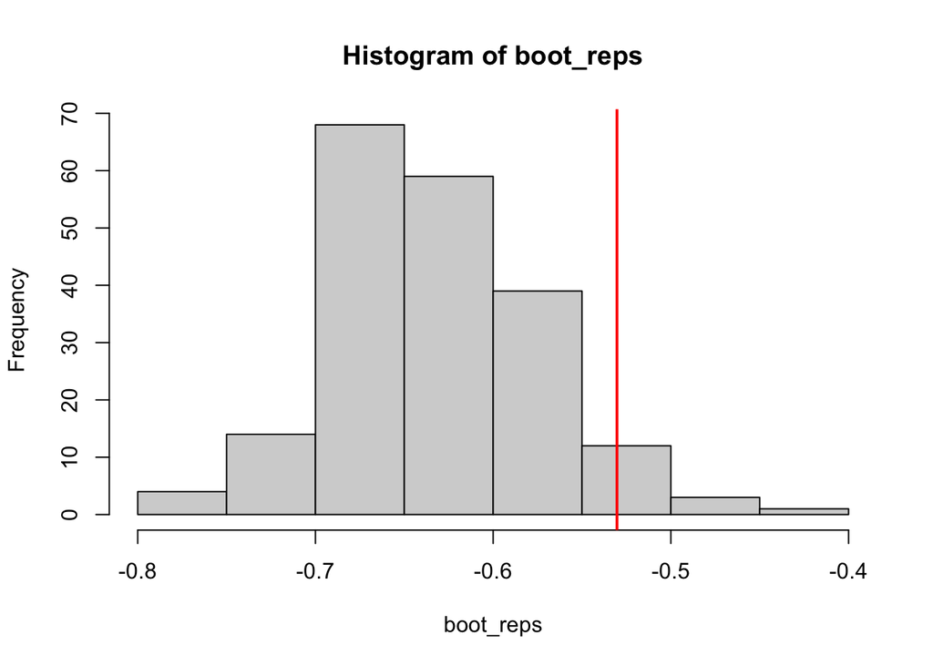

```r
B <- 200; # Number of bootstrap replicates.
nsamp <- nrow(original_data);

boot_reps <- rep(NA, B);
for( i in 1:B ) {
  # To get a resample, we need to first pick out indices, and grab those rows of
  # the data frame, since passing a data frame directly to sample() breaks things.
  # Unfortunately, there are a couple of things wrong with this line. Correct it.
  resamp_inds <-sample( 1:nsamp, nsamp, replace=TRUE );
  # Use resampled indices to pick out corresponding rows of the original data
  resamp_data <- original_data[ resamp_inds, ];

  # The following line is incorrect. Correct it.
  boot_reps[i] <- compute_rhohat( resamp_data );
}

# This histogram will look bizarre until the above errors are corrected.
hist( boot_reps )
abline( v=rhotrue, lwd=2, col='red' );
```

Okay, now use the bootstrap replicates to estimate the variance of $\hat{\rho}$ and construct a 95% bootstrap confidence interval for $\rho$.

```r
rhohat_variance = var(boot_reps)
rhohat_variance
```

```
## [1] 0.003434707
```

Does the CI contain the true value of $\rho$? Compute the width of your bootstrap-based CI.

```r
bootstrap_CI = unname(quantile(boot_reps, c(.025, .975)))
bootstrap_CI
```

```
## [1] -0.7439209 -0.5122939
```

Compare the width of this confidence interval with the simulation-based CI you constructed earlier. Which is wider? Is this surprising? Why or why not?

```r
bootstrap_CI[2] - bootstrap_CI[1]
```

```
## [1] 0.231627
```

**One particular thing to think about:** the simulation-based CI made a very specific assumption about the model. This assumption happened to be correct in this case, but we are seldom so lucky in the real world. In contrast, the bootstrap-based CI doesn’t care about the data-generating model at all!

Of course, in general, these two CIs are random, and so if we want to compare them in a fair way, we should repeat the above procedure many times.

**Optional exercise:** write code to repeatedly generate random data from the normal model, construct both the simulation- and bootstrap-based CIs, and compare their coverage rates (i.e., how often they caught the true value of $\rho$) and average widths.

**Optional exercise:** try changing the parameter `B` (the number of bootstrap replicates to use). How does the bootstrap-based CI change? Does its coverage rate change? Does its width change?

**Optional exercise:** the simulation-based approach worked well here because its model assumption (that the data is normal) was in fact correct. Look on Wikipedia for other ways to generate correlated data. Pick one and repeat the above experiment, still comparing a simulation-based approach (one that assumes, now incorrectly, that the data is normal) with a bootstrap-based CI. What do you observe?